# Практика · GAN

> Лекція: lecture.html · Тест: quiz.html · Домашнє завдання: homework.html

> ⏱ Зошит навчає одного суддю, **девʼять** GAN (три конфігурації на трьох зернах) і **три** VAE. Заміряно на чотирьох ядрах без відеокарти, серійним прогоном: **близько чотирьох хвилин** — у шести прогонах вийшло від 208 до 376 секунд, і розкид дає завантаження машини, а не сам зошит. Чотири пʼятих цього часу займає навчання девʼяти GAN; воно й друкує рядок «девʼять GAN навчено за … с», тож звіряйся з ним. Рахунок іде в один потік — на таких дрібних мережах так і швидше, і відтворюваніше.

Тут кожне твердження лекції перетворюється на число.

1. **Насичена й ненасичена втрата генератора** — рахуємо градієнт руками й звіряємо з `torch.autograd`.
2. **Суддя** — класифікатор шести фігур, і перевірка, що на справжніх даних йому легко.
3. **Калібрування метрики** — вісім завідомо поганих наборів. Метрика, яка не поставить «лише кола» гірше за робочу модель, до роботи не допускається.
4. **Колапс мод** — скільки з шести фігур доживає до кінця навчання.
5. **Три конфігурації на трьох зернах** — і перевірка найпоширенішої поради «послаб дискримінатора».
6. **Криві втрат** — і доказ, що за ними не видно нічого.
7. **Чому першим гине кільце** — замір крихкості фігур.
8. **GAN проти VAE** — однією метрикою: різкість проти покриття.

**Мережа не потрібна:** усі зображення ми малюємо формулами.

```python
import time
import numpy as np
import torch
import torch.nn as nn
import torch.nn.functional as F
import scipy
from scipy import linalg

# зерна фіксуємо на самому початку: без них числа нижче не збіжаться з лекцією
torch.manual_seed(0)

# один потік, а не чотири. Мережі тут крихітні, і чотири потоки більше часу
# домовляються між собою, ніж рахують. Друга причина важливіша за швидкість:
# під кількома потоками float-суми йдуть в іншому порядку, і числа пливуть.
torch.set_num_threads(1)

notebook_started = time.perf_counter()

print("torch      :", torch.__version__)
print("numpy      :", np.__version__)
print("scipy      :", scipy.__version__)
print("потоків CPU:", torch.get_num_threads())
```

```
torch      : 2.10.0+cpu
numpy      : 2.5.1
scipy      : 1.16.0
потоків CPU: 1
```

## 1 · Дві втрати генератора: рахуємо градієнт руками

Найдешевший замір теми — він не потребує ані даних, ані навчання, і при цьому пояснює рядок коду, який стоїть у кожній реалізації GAN.

Дискримінатор видає одне число `s` (його звуть **логіт**), а ймовірність «це справжнє» дістають із нього сигмоїдою: `D = 1 / (1 + exp(-s))`.

Оригінальна стаття пропонує генераторові **мінімізувати** `log(1 - D)` — тобто знижувати впевненість дискримінатора в тому, що підробка фальшива. На практиці так ніхто не робить. На початку навчання дискримінатор легко розрізняє, `D` близьке до нуля — і градієнт цієї втрати теж близький до нуля. Генератор стоїть саме тоді, коли йому найбільше треба вчитись.

Замість цього генератор **мінімізує** `-log D`. Точка оптимуму та сама, а поведінка градієнта протилежна. Похідні по логіту виводяться в один рядок:

- насичена: похідна `log(1 - sigmoid(s))` по `s` дорівнює `-sigmoid(s)`, тобто `-D`;
- ненасичена: похідна `-log sigmoid(s)` по `s` дорівнює `sigmoid(s) - 1`, тобто `D - 1`.

Отже модуль градієнта — це `D` у першому випадку й `1 - D` у другому. Порахуємо обидва числа й подивимось, у скільки разів вони різняться.

```python
def sigmoid(s):
    return 1.0 / (1.0 + np.exp(-s))


print("%-9s %-10s %-15s %-16s %s" %
      ("логіт s", "D = σ(s)", "|град| насич.", "|град| ненасич.", "у скільки разів"))
print("-" * 68)

saturation_table = []
for logit in [-4.0, -3.0, -2.0, -1.0, 0.0, 1.0, 2.0]:
    d_value = sigmoid(logit)
    grad_saturating = d_value              # модуль від -D
    grad_nonsaturating = 1.0 - d_value     # модуль від D - 1
    saturation_table.append((logit, d_value, grad_saturating, grad_nonsaturating))
    print("%-9.1f %-10.4f %-15.4f %-16.4f %.1f" %
          (logit, d_value, grad_saturating, grad_nonsaturating,
           grad_nonsaturating / grad_saturating))
```

```
логіт s   D = σ(s)   |град| насич.   |град| ненасич.  у скільки разів
--------------------------------------------------------------------
-4.0      0.0180     0.0180          0.9820           54.6
-3.0      0.0474     0.0474          0.9526           20.1
-2.0      0.1192     0.1192          0.8808           7.4
-1.0      0.2689     0.2689          0.7311           2.7
0.0       0.5000     0.5000          0.5000           1.0
1.0       0.7311     0.7311          0.2689           0.4
2.0       0.8808     0.8808          0.1192           0.1
```

Тепер обовʼязкова звірка «наша реалізація проти бібліотечної»: попросимо `torch.autograd` порахувати ті самі похідні автоматично.

```python
logits = torch.tensor([-4.0, -3.0, -2.0, -1.0, 0.0, 1.0, 2.0], requires_grad=True)
loss_saturating = torch.log(1 - torch.sigmoid(logits)).sum()
grad_saturating_torch = torch.autograd.grad(loss_saturating, logits)[0].abs().numpy()

logits_again = torch.tensor([-4.0, -3.0, -2.0, -1.0, 0.0, 1.0, 2.0], requires_grad=True)
loss_nonsaturating = (-torch.log(torch.sigmoid(logits_again))).sum()
grad_nonsaturating_torch = torch.autograd.grad(loss_nonsaturating, logits_again)[0].abs().numpy()

by_hand_saturating = np.array([row[2] for row in saturation_table])
by_hand_nonsaturating = np.array([row[3] for row in saturation_table])

assert np.allclose(by_hand_saturating, grad_saturating_torch, atol=1e-6), "насичена розійшлася!"
assert np.allclose(by_hand_nonsaturating, grad_nonsaturating_torch, atol=1e-6), "ненасичена розійшлася!"

print("руками  :", np.round(by_hand_saturating, 4))
print("autograd:", np.round(grad_saturating_torch, 4))
print("✅ збігається — і для насиченої, і для ненасиченої")
```

```
руками  : [0.018  0.0474 0.1192 0.2689 0.5    0.7311 0.8808]
autograd: [0.018  0.0474 0.1192 0.2689 0.5    0.7311 0.8808]
✅ збігається — і для насиченої, і для ненасиченої
```

Головний рядок таблиці — перший. При `s = -4` дискримінатор дає `D = 0.0180`: він майже впевнений, що бачить підробку. Насичена втрата має тут градієнт **0.0180**, ненасичена — **0.9820**, тобто у **54.6 раза** більший. Через це в кожній реальній реалізації GAN стоїть ненасичений варіант, і ми теж беремо його.

## 2 · Датасет: ті самі шість фігур

Наскрізний приклад усього блоку — шість фігур 28×28 із випадковим центром, випадковим радіусом і шумом σ = 0.06. Генератор фігур дослівно той самий, що в темі 16 «Самонаглядове навчання», тільки шум менший: намалювати фігуру складніше, ніж упізнати, і зайвий шум заважає читати результат.

```python
SHAPE_NAMES = ["коло", "квадрат", "ромб", "кільце", "хрест", "трикутник"]


def draw_shape(kind, rng, size=28, jitter=5, noise=0.06, center=None, radius=None):
    # Малює одну фігуру як масив 28 на 28 зі значеннями 0..1.
    image = np.zeros((size, size), dtype=np.float32)
    if center is None:
        center_y = size / 2 + rng.integers(-jitter, jitter + 1)
        center_x = size / 2 + rng.integers(-jitter, jitter + 1)
    else:
        center_y, center_x = center
    if radius is None:
        radius = rng.integers(5, 9)

    # відстані кожного пікселя від центра — з них складаються всі шість фігур
    yy, xx = np.mgrid[0:size, 0:size]
    dy, dx = yy - center_y, xx - center_x

    if kind == 0:                                    # коло
        image[dy * dy + dx * dx <= radius * radius] = 1.0
    elif kind == 1:                                  # квадрат
        image[(np.abs(dy) <= radius * 0.85) & (np.abs(dx) <= radius * 0.85)] = 1.0
    elif kind == 2:                                  # ромб
        image[np.abs(dy) + np.abs(dx) <= radius] = 1.0
    elif kind == 3:                                  # кільце
        distance = dy * dy + dx * dx
        image[(distance <= radius * radius) & (distance >= (radius - 3) ** 2)] = 1.0
    elif kind == 4:                                  # хрест
        image[(np.abs(dy) <= 2) & (np.abs(dx) <= radius)] = 1.0
        image[(np.abs(dx) <= 2) & (np.abs(dy) <= radius)] = 1.0
    else:                                            # трикутник
        image[(dy >= -radius * 0.8) & (dy <= radius * 0.8)
              & (np.abs(dx) <= (dy + radius * 0.8) * 0.6)] = 1.0

    if noise > 0:
        image = image + rng.normal(0, noise, image.shape).astype(np.float32)
    return np.clip(image, 0, 1)


def make_dataset(count, rng):
    # Повертає (count, 1, 28, 28) і (count,). Класів шість, порівну.
    images = np.zeros((count, 1, 28, 28), dtype=np.float32)
    labels = np.zeros(count, dtype=np.int64)
    for i in range(count):
        kind = i % 6                       # рівно по шостій частині кожного класу
        images[i, 0] = draw_shape(kind, rng)
        labels[i] = kind
    return torch.from_numpy(images), torch.from_numpy(labels)


rng = np.random.default_rng(42)
x_train, y_train = make_dataset(1800, rng)          # на цьому вчаться і суддя, і GAN
x_test, y_test = make_dataset(600, rng)             # перевірка судді
x_reference, y_reference = make_dataset(600, rng)   # еталонна купа для FID

print("навчальні :", tuple(x_train.shape))
print("перевірні :", tuple(x_test.shape))
print("еталон FID:", tuple(x_reference.shape))
print("частка кожного класу: %.4f" % (1 / 6))
```

```
навчальні : (1800, 1, 28, 28)
перевірні : (600, 1, 28, 28)
еталон FID: (600, 1, 28, 28)
частка кожного класу: 0.1667
```

Подивимось на всі шість фігур очима й порахуємо, скільки в кожній «намальованих» пікселів. Це число знадобиться пізніше, коли ми питатимемо, чому одні класи гинуть раніше за інших.

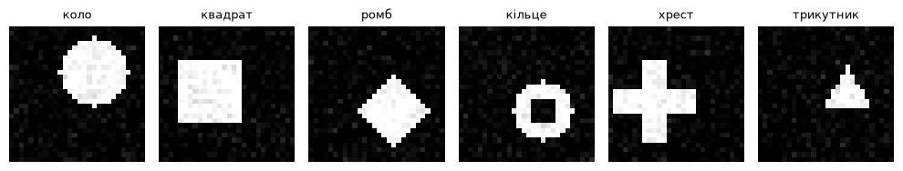

```
фігура      частка яскравих пікселів
коло        0.1756
квадрат     0.1544
ромб        0.1310
кільце      0.1237
хрест       0.1479
трикутник   0.0868
```

```python
import matplotlib.pyplot as plt

figure, axes = plt.subplots(1, 6, figsize=(10, 2.0))
for kind in range(6):
    axes[kind].imshow(x_train[kind, 0], cmap="gray", vmin=0, vmax=1)
    axes[kind].set_title(SHAPE_NAMES[kind], fontsize=9)
    axes[kind].axis("off")
plt.tight_layout()
plt.show()

print("%-11s %s" % ("фігура", "частка яскравих пікселів"))
bright_share = []
for kind in range(6):
    same_class = x_train[kind::6, 0].numpy()
    share = float((same_class > 0.5).mean())
    bright_share.append(share)
    print("%-11s %.4f" % (SHAPE_NAMES[kind], share))
```

## 3 · Суддя

Згенеровану картинку не можна оцінити «на око» в тексті, де числа мусить друкувати зошит. Тому нам потрібен **суддя** — окремий класифікатор шести фігур, навчений на справжніх даних.

У нього три ролі:

- сказати, **яка це фігура** — з цього ми порахуємо покриття класів;
- дати **впевненість** — і показати, чому їй не можна вірити;
- дати **64 числа ознак** із передостаннього шару — на них будуватимемо FID.

```python
def conv_block(in_channels, out_channels):
    # Один типовий блок: Conv → ReLU → Pool. Той самий, що в темах 12 і 16.
    return nn.Sequential(
        nn.Conv2d(in_channels, out_channels, kernel_size=3, padding=1),
        nn.ReLU(),
        nn.MaxPool2d(2),
    )


class Judge(nn.Module):
    # Класифікатор фігур. Шар squeeze дає 64 числа — саме їх бере FID.
    def __init__(self):
        super().__init__()
        self.body = nn.Sequential(conv_block(1, 8), conv_block(8, 16),
                                  conv_block(16, 32), nn.Flatten())
        self.squeeze = nn.Linear(288, 64)
        self.head = nn.Linear(64, 6)

    def features(self, x):
        return F.relu(self.squeeze(self.body(x)))

    def forward(self, x):
        return self.head(self.features(x))


def train_judge(images, labels, seed=0, epochs=8, batch_size=64, lr=3e-3):
    torch.manual_seed(seed)
    model = Judge()
    optimizer = torch.optim.AdamW(model.parameters(), lr=lr)
    count = len(images)
    for epoch in range(epochs):
        order = torch.randperm(count)
        for start in range(0, count, batch_size):
            batch = order[start:start + batch_size]
            optimizer.zero_grad()
            F.cross_entropy(model(images[batch]), labels[batch]).backward()
            optimizer.step()
    model.eval()
    return model


judge_started = time.perf_counter()
judge = train_judge(x_train, y_train)
print("суддя навчений за %.1f с" % (time.perf_counter() - judge_started))

with torch.no_grad():
    judge_accuracy = float((judge(x_test).argmax(1) == y_test).float().mean())
print("точність судді на справжніх фігурах: %.4f" % judge_accuracy)
```

```
суддя навчений за 4.2 с
точність судді на справжніх фігурах: 0.9950
```

Задача для судді тривіальна — і це саме те, що нам треба. Якщо на справжніх фігурах він майже не помиляється, то будь-яка його невпевненість на згенерованому щось означає.

Тепер два інструменти, якими ми міритимемо генерацію.

**Покриття класів.** Проганяємо 600 згенерованих картинок крізь суддю й дивимось, скільки з шести класів отримали хоч 5 % вибірки. Максимум — 6.

**FID.** Відстань Фреше між двома купами ознак: рахуємо середнє й коваріаційну матрицю для справжніх і для згенерованих, і міряємо, наскільки різні ці два хмарні описи. Формула нижче — точна відстань між двома гаусіанами.

> ⚠️ Наш FID **не порівнюваний з опублікованими числами**. Справжній FID рахують на ознаках Inception, навченого на ImageNet; ми беремо ознаки власного судді, який знає рівно шість фігур. Наше число годиться, щоб порівнювати наші моделі між собою, і не годиться, щоб цитувати поруч зі статтями.

```python
@torch.no_grad()
def judge_report(model, images):
    # Повертає частки шести класів і середню впевненість.
    probabilities = F.softmax(model(images), dim=1)
    confidence, predicted = probabilities.max(1)
    shares = np.bincount(predicted.numpy(), minlength=6) / len(images)
    return shares, float(confidence.mean())


@torch.no_grad()
def feature_cloud(model, images, batch_size=256):
    # 64 числа на картинку — та купа, між якими рахується відстань Фреше.
    parts = []
    for start in range(0, len(images), batch_size):
        parts.append(model.features(images[start:start + batch_size]).numpy())
    return np.concatenate(parts)


def frechet_distance(cloud_a, cloud_b, eps=1e-6):
    # |μa - μb|² + tr(Σa + Σb - 2·(Σa·Σb)^(1/2))
    mean_a, mean_b = cloud_a.mean(0), cloud_b.mean(0)
    # частина з 64 ознак завжди нульова (ReLU їх погасив), і коваріаційна
    # матриця через це вироджена. Крихітна добавка на діагональ робить корінь
    # обчислюваним і майже не змінює число — так роблять і в справжніх FID
    regulariser = eps * np.eye(cloud_a.shape[1])
    cov_a = np.cov(cloud_a, rowvar=False) + regulariser
    cov_b = np.cov(cloud_b, rowvar=False) + regulariser
    difference = mean_a - mean_b
    root = linalg.sqrtm(cov_a.dot(cov_b))
    if np.iscomplexobj(root):
        root = root.real
    return float(difference.dot(difference) + np.trace(cov_a) + np.trace(cov_b)
                 - 2 * np.trace(root))


def midtone_share(images):
    # частка пікселів, які ані чорні, ані білі: найпростіша міра розмитості
    values = images.numpy()
    return float(((values > 0.25) & (values < 0.75)).mean())


reference_cloud = feature_cloud(judge, x_reference)


def score(images):
    # Три числа на кожен набір: покриття, FID і впевненість судді.
    shares, confidence = judge_report(judge, images)
    covered = int((shares >= 0.05).sum())
    return covered, frechet_distance(feature_cloud(judge, images), reference_cloud), confidence, shares


# перевірка формули: відстань купи до себе самої мусить бути нулем
self_distance = abs(frechet_distance(reference_cloud, reference_cloud))
assert self_distance < 1e-4, "відстань до себе не нуль — формула зламана"
print("FID купи до себе самої: %.6f  ✅ нуль, як і має бути" % self_distance)
```

```
FID купи до себе самої: 0.000000  ✅ нуль, як і має бути
```

## 4 · Калібрування: спершу перевіряємо метрику, потім модель

Це найважливіша клітинка зошита, і пропустити її не можна.

Метрика генерації — не термометр, який просто працює. Вона може мовчки міряти не те, і тоді всі числа, поміряні нею, доведеться викинути. Тому перед першим використанням її проганяють через набір **завідомо поганих** зразків.

Головний рядок майбутньої таблиці — «лише кола». Це повний колапс мод: один клас із шести. Метрика, яка ставить його **краще** за робочу модель, до роботи не допускається.

```python
calibration_rng = np.random.default_rng(7)


def only_kinds(kinds, count=600):
    # Набір, у якому є лише перелічені класи, — модель колапсу мод.
    images = np.zeros((count, 1, 28, 28), dtype=np.float32)
    for i in range(count):
        images[i, 0] = draw_shape(kinds[i % len(kinds)], calibration_rng)
    return torch.from_numpy(images)


# «розмита каша»: справжні фігури, двічі згладжені вікном 5 на 5
blurred = F.avg_pool2d(x_test, 5, stride=1, padding=2)
blurred = F.avg_pool2d(blurred, 5, stride=1, padding=2)

calibration_sets = [
    ("справжні, інша вибірка", x_test),
    ("лише кола", only_kinds([0])),
    ("кола + квадрати", only_kinds([0, 1])),
    ("розмита каша", blurred),
    ("середнє всіх фігур", x_train.mean(0, keepdim=True).repeat(600, 1, 1, 1)),
    ("усе чорне", torch.zeros(600, 1, 28, 28)),
    ("чистий шум", torch.rand(600, 1, 28, 28)),
    ("усе біле", torch.ones(600, 1, 28, 28)),
]

print("%-24s %8s %12s %10s" % ("що подаємо", "класів", "FID", "впевненість"))
print("-" * 58)
calibration_rows = []
for name, images in calibration_sets:
    covered, fid, confidence, _ = score(images)
    calibration_rows.append((name, covered, fid, confidence))
    print("%-24s %8d %12.4f %10.4f" % (name, covered, fid, confidence))
```

```
що подаємо                 класів          FID впевненість
----------------------------------------------------------
```

```
справжні, інша вибірка          6       1.1582     0.9899
```

```
лише кола                       1     483.8364     0.9771
```

```
кола + квадрати                 2     466.8041     0.9806
```

```
розмита каша                    2     918.3200     0.8103
```

```
середнє всіх фігур              1    1035.5173     0.5218
усе чорне                       1    1133.5891     0.9957
```

```
чистий шум                      2    1089.8743     0.8004
усе біле                        1    1311.2006     0.5554
```

Читай перший рядок і другий разом.

**Справжні фігури з іншої вибірки** дають FID близько одиниці — це базова лінія, шум оцінки, а не відстань. Друкувати її поруч обовʼязково, інакше читач сприйме за нуль будь-яке мале число.

**«Лише кола»** дають FID у сотні разів більший і покриття 1. Метрика впоралася: повний колапс мод вона ставить дуже погано. Саме цієї перевірки не витримала слабша версія метрики, і в блоці вже був випадок, коли «лише кола» опинилися **краще** за робочу модель.

І звернімо увагу на останній стовпчик уже тут: на «всьому чорному» суддя впевнений сильніше, ніж на справжніх фігурах. Впевненість — не міра якості, і далі ми побачимо це ще двічі.

```python
real_baseline_fid = calibration_rows[0][2]
circles_only_fid = calibration_rows[1][2]
print("базова лінія (справжні проти справжніх): %.4f" % real_baseline_fid)
print("повний колапс мод (лише кола)          : %.4f" % circles_only_fid)
print("у скільки разів гірше                  : %.1f" % (circles_only_fid / real_baseline_fid))
assert circles_only_fid > 50 * real_baseline_fid, "метрика сліпа до колапсу — далі йти не можна"
print("✅ метрика бачить колапс мод — можна міряти")
```

```
базова лінія (справжні проти справжніх): 1.1582
повний колапс мод (лише кола)          : 483.8364
у скільки разів гірше                  : 417.7
✅ метрика бачить колапс мод — можна міряти
```

## 5 · Крихітний DCGAN

Тепер самі мережі. Генератор бере 16 випадкових чисел і робить із них картинку 28×28; дискримінатор бере картинку й видає одне число.

Архітектура — DCGAN у найменшому вигляді: у генератора `ConvTranspose2d`, які подвоюють сторону (7 → 14 → 28), у дискримінатора звичайні `Conv2d` із кроком 2, які її вдвічі зменшують. `Tanh` на виході генератора означає, що картинки живуть у відрізку від −1 до 1, тому справжні дані ми теж туди переносимо.

```python
LATENT = 16          # стільки випадкових чисел на вході генератора


class Generator(nn.Module):
    def __init__(self, latent=LATENT, width=24):
        super().__init__()
        self.width = width
        self.fc = nn.Linear(latent, width * 7 * 7)
        self.net = nn.Sequential(
            nn.BatchNorm2d(width), nn.ReLU(),
            nn.ConvTranspose2d(width, width // 2, 4, stride=2, padding=1),   # 7 → 14
            nn.BatchNorm2d(width // 2), nn.ReLU(),
            nn.ConvTranspose2d(width // 2, 1, 4, stride=2, padding=1),       # 14 → 28
            nn.Tanh())

    def forward(self, z):
        return self.net(self.fc(z).view(-1, self.width, 7, 7))


class MinibatchStd(nn.Module):
    # Канонічний рецепт проти колапсу: додати в дискримінатор канал,
    # у якому лежить розкид активацій ПО ПАКЕТУ. Пакет із однакових
    # картинок дає нуль, і дискримінатор може це помітити.
    def forward(self, x):
        spread = x.std(0, unbiased=False).mean()
        return torch.cat([x, spread.expand(x.size(0), 1, x.size(2), x.size(3))], dim=1)


class Discriminator(nn.Module):
    def __init__(self, width=24, minibatch_std=False):
        super().__init__()
        self.minibatch = MinibatchStd() if minibatch_std else None
        extra = 1 if minibatch_std else 0
        self.conv1 = nn.Conv2d(1, width // 2, 4, stride=2, padding=1)        # 28 → 14
        self.conv2 = nn.Conv2d(width // 2 + extra, width, 4, stride=2, padding=1)  # 14 → 7
        self.fc = nn.Linear(width * 7 * 7, 1)

    def forward(self, x):
        h = F.leaky_relu(self.conv1(x), 0.2)
        if self.minibatch is not None:
            h = self.minibatch(h)
        h = F.leaky_relu(self.conv2(h), 0.2)
        return self.fc(h.flatten(1))


generator_params = sum(p.numel() for p in Generator().parameters())
discriminator_params = sum(p.numel() for p in Discriminator().parameters())
discriminator_mb_params = sum(p.numel() for p in Discriminator(minibatch_std=True).parameters())
print("параметрів у генераторі        :", generator_params)
print("параметрів у дискримінаторі    :", discriminator_params)
print("те саме з minibatch std        :", discriminator_mb_params,
      "(+%d)" % (discriminator_mb_params - discriminator_params))
print("латентних чисел на вході       :", LATENT)

# minibatch std справді бачить розкид: на пакеті з однакових картинок він нуль
same = torch.zeros(8, 4, 6, 6)
varied = torch.randn(8, 4, 6, 6)
print("канал розкиду на однакових картинках: %.4f"
      % float(MinibatchStd()(same)[0, -1, 0, 0]))
print("канал розкиду на різних картинках   : %.4f"
      % float(MinibatchStd()(varied)[0, -1, 0, 0]))
```

```
параметрів у генераторі        : 24877
параметрів у дискримінаторі    : 6013
те саме з minibatch std        : 6397 (+384)
латентних чисел на вході       : 16
канал розкиду на однакових картинках: 0.0000
канал розкиду на різних картинках   : 0.9163
```

## 6 · Навчання: два кроки в одному циклі

Один крок навчання GAN — це два оновлення підряд.

1. **Дискримінатор.** Показуємо йому пакет справжніх картинок із міткою «справжнє» і пакет підробок із міткою «підробка». Звичайна бінарна класифікація.
2. **Генератор.** Проганяємо ті самі підробки крізь дискримінатора ще раз (він уже змінився) і кажемо: мітка «справжнє». Дискримінатора при цьому не чіпаємо — градієнт іде крізь нього до генератора.

Оптимізатор — `Adam` із `betas=(0.5, 0.999)`. Перше число — це інерція градієнта: за замовчуванням `0.9`, тобто оптимізатор довго памʼятає, куди йшов. У грі двох мереж «куди йшов» застаріває щокроку, бо суперник змінився, і довга памʼять шкодить. `0.5` — рецепт зі статті про DCGAN, і він справді потрібен.

Функція нижче зберігає **знімки** генератора на кількох епохах — щоб потім відповісти на питання, чи колапс минає з часом.

```python
CHECKPOINTS = [8, 14, 20]


def train_gan(x_real, seed, width=24, lr_generator=2e-4, lr_discriminator=2e-4,
              minibatch_std=False, batch_size=64, latent=LATENT):
    torch.manual_seed(seed)
    generator = Generator(latent, width)
    discriminator = Discriminator(width, minibatch_std)
    opt_g = torch.optim.Adam(generator.parameters(), lr=lr_generator, betas=(0.5, 0.999))
    opt_d = torch.optim.Adam(discriminator.parameters(), lr=lr_discriminator, betas=(0.5, 0.999))

    scaled = x_real * 2 - 1              # Tanh на виході, отже дані від −1 до 1
    count = len(scaled)
    bce = F.binary_cross_entropy_with_logits
    ones = torch.ones(batch_size, 1)
    zeros = torch.zeros(batch_size, 1)

    loss_history = []
    snapshots = {}
    for epoch in range(1, max(CHECKPOINTS) + 1):
        order = torch.randperm(count)
        sum_d = sum_g = 0.0
        batches = 0
        for start in range(0, count - batch_size + 1, batch_size):
            real = scaled[order[start:start + batch_size]]
            fake = generator(torch.randn(batch_size, latent))

            # крок 1: дискримінатор учиться відрізняти. detach() відрізає
            # градієнт від генератора — його ми тут не чіпаємо
            opt_d.zero_grad()
            loss_d = bce(discriminator(real), ones) + bce(discriminator(fake.detach()), zeros)
            loss_d.backward()
            opt_d.step()

            # крок 2: генератор бреше про мітку. Це та сама ненасичена втрата
            # -log D, з якої почався зошит
            opt_g.zero_grad()
            loss_g = bce(discriminator(fake), ones)
            loss_g.backward()
            opt_g.step()

            sum_d += loss_d.item()
            sum_g += loss_g.item()
            batches += 1

        loss_history.append((sum_d / batches, sum_g / batches))
        if epoch in CHECKPOINTS:
            generator.eval()
            with torch.no_grad():
                fixed = torch.Generator().manual_seed(5000 + seed)
                snapshots[epoch] = ((generator(torch.randn(600, latent, generator=fixed)) + 1) / 2).clone()
            generator.train()

    generator.eval()
    return generator, loss_history, snapshots


# дешева перевірка, що цикл узагалі крутиться: одна епоха на ста картинках
smoke_generator, smoke_losses, _ = train_gan(x_train[:128], seed=0)
print("пробний прогін: епох %d, остання втрата D %.4f, втрата G %.4f"
      % (len(smoke_losses), smoke_losses[-1][0], smoke_losses[-1][1]))
print("контрольні точки, на яких зберігаємо знімки:", CHECKPOINTS)
```

```
пробний прогін: епох 20, остання втрата D 0.8576, втрата G 0.7683
контрольні точки, на яких зберігаємо знімки: [8, 14, 20]
```

### Три конфігурації

Три точки на одній осі — **співвідношення сил генератора й дискримінатора**:

- **дискримінатор повільніший** — його швидкість навчання опущено вчетверо, до `5e-5`. Це найпоширеніша порада форумів: «дискримінатор надто сильний, послаб його»;
- **однакові кроки** — обидва мають `2e-4`. Це замовчування DCGAN;
- **генератор швидший** — швидкість генератора піднято до `5e-4`, дискримінатор лишається на `2e-4`.

Зверни увагу на пастку, заради якої взято саме ці три точки. Відношення `lr_generator / lr_discriminator` дорівнює **4** у першій конфігурації, **1** у другій і **2.5** у третій. Якщо справа у відношенні, перша й третя мають бути схожими між собою й обидві — кращими за другу.

Кожна конфігурація йде на **трьох зернах**. Різниця, менша за розкид по зернах, не є різницею — це правило курсу з теми 26 «Одноетапні детектори».

```python
CONFIGS = [
    ("дискримінатор повільніший", {"lr_discriminator": 5e-5}),
    ("однакові кроки", {}),
    ("генератор швидший", {"lr_generator": 5e-4}),
]

gan_started = time.perf_counter()
results = {}
for name, options in CONFIGS:
    results[name] = {"covered": {e: [] for e in CHECKPOINTS},
                     "fid": {e: [] for e in CHECKPOINTS},
                     "confidence": {e: [] for e in CHECKPOINTS},
                     "shares": {e: [] for e in CHECKPOINTS},
                     "midtones": {e: [] for e in CHECKPOINTS},
                     "losses": None, "samples": None}
    for seed in [0, 1, 2]:
        generator, losses, snapshots = train_gan(x_train, seed, **options)
        if seed == 0:
            results[name]["losses"] = losses
            results[name]["samples"] = snapshots[CHECKPOINTS[-1]]
        for epoch in CHECKPOINTS:
            covered, fid, confidence, shares = score(snapshots[epoch])
            results[name]["covered"][epoch].append(covered)
            results[name]["fid"][epoch].append(fid)
            results[name]["confidence"][epoch].append(confidence)
            results[name]["shares"][epoch].append(shares)
            results[name]["midtones"][epoch].append(midtone_share(snapshots[epoch]))
    final = results[name]["covered"][20]
    print("%-28s класів %.2f  %s" % (name, np.mean(final), final))

print()
print("девʼять GAN навчено за %.0f с" % (time.perf_counter() - gan_started))
```

```
дискримінатор повільніший    класів 2.33  [3, 3, 1]
```

```
однакові кроки               класів 3.00  [3, 3, 3]
```

```
генератор швидший            класів 4.67  [5, 5, 4]

девʼять GAN навчено за 206 с
```

## 7 · Головна таблиця теми

```python
LAST = CHECKPOINTS[-1]
print("%-28s %8s %14s %12s %12s" %
      ("конфігурація", "класів", "по зернах", "FID", "впевненість"))
print("-" * 80)
for name, _ in CONFIGS:
    data = results[name]
    print("%-28s %8.2f %14s %12.2f %12.4f" %
          (name, np.mean(data["covered"][LAST]), str(data["covered"][LAST]),
           np.mean(data["fid"][LAST]), np.mean(data["confidence"][LAST])))
print("-" * 80)
print("%-28s %8d %14s %12.4f %12.4f" %
      ("справжні фігури", 6, "[6, 6, 6]", real_baseline_fid, calibration_rows[0][3]))
```

```
конфігурація                   класів      по зернах          FID  впевненість
--------------------------------------------------------------------------------
дискримінатор повільніший        2.33      [3, 3, 1]       724.94       0.9129
однакові кроки                   3.00      [3, 3, 3]       569.69       0.8213
генератор швидший                4.67      [5, 5, 4]       249.33       0.8116
--------------------------------------------------------------------------------
справжні фігури                     6      [6, 6, 6]       1.1582       0.9899
```

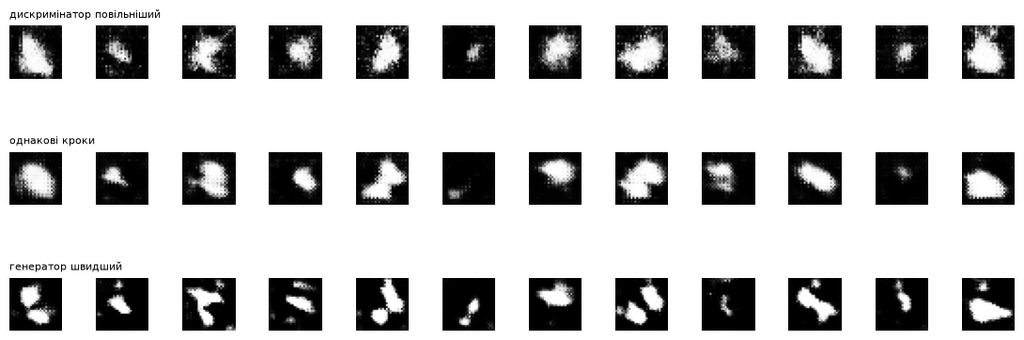

```
по дванадцять зразків кожної конфігурації, зерно 0
```

```python
figure, axes = plt.subplots(len(CONFIGS), 12, figsize=(11, 4.4))
for row, (name, _) in enumerate(CONFIGS):
    samples = results[name]["samples"]
    for column in range(12):
        axes[row, column].imshow(samples[column, 0], cmap="gray", vmin=0, vmax=1)
        axes[row, column].axis("off")
    axes[row, 0].set_title(name, fontsize=8, loc="left")
plt.tight_layout()
plt.show()
print("по дванадцять зразків кожної конфігурації, зерно 0")
```

## 8 · Куди поділись фігури

Покриття — це одне число. Подивімось на самі частки: яких фігур генератор намалював багато, а яких не намалював зовсім.

```python
print("%-28s %s" % ("конфігурація", "  ".join("%-9s" % n for n in SHAPE_NAMES)))
print("-" * 90)
for name, _ in CONFIGS:
    shares = results[name]["shares"][LAST][0]        # зерно 0
    print("%-28s %s" % (name, "  ".join("%-9.2f" % v for v in shares)))
print("-" * 90)
print("%-28s %s" % ("рівномірно було б", "  ".join("%-9.2f" % (1 / 6) for _ in range(6))))
```

```
конфігурація                 коло       квадрат    ромб       кільце     хрест      трикутник
------------------------------------------------------------------------------------------
дискримінатор повільніший    0.11       0.49       0.02       0.00       0.02       0.36
однакові кроки               0.22       0.38       0.02       0.00       0.00       0.39
генератор швидший            0.33       0.14       0.16       0.04       0.19       0.14
------------------------------------------------------------------------------------------
рівномірно було б            0.17       0.17       0.17       0.17       0.17       0.17
```

```python
for name, _ in CONFIGS:
    print(name)
    for seed in range(3):
        shares = results[name]["shares"][LAST][seed]
        print("   зерно %d: класів %d  FID %7.2f  впевненість %.4f  напівтони %.4f  %s"
              % (seed, results[name]["covered"][LAST][seed],
                 results[name]["fid"][LAST][seed],
                 results[name]["confidence"][LAST][seed],
                 results[name]["midtones"][LAST][seed],
                 " ".join("%.3f" % v for v in shares)))
print()
print("порядок класів:", " ".join(SHAPE_NAMES))
```

```
дискримінатор повільніший
   зерно 0: класів 3  FID  544.70  впевненість 0.8660  напівтони 0.1157  0.112 0.493 0.017 0.000 0.020 0.358
   зерно 1: класів 3  FID  624.06  впевненість 0.8729  напівтони 0.1391  0.060 0.562 0.002 0.000 0.002 0.375
   зерно 2: класів 1  FID 1006.06  впевненість 0.9998  напівтони 0.0500  0.000 0.000 0.000 0.000 0.000 1.000
однакові кроки
   зерно 0: класів 3  FID  604.47  впевненість 0.8579  напівтони 0.0747  0.220 0.377 0.017 0.000 0.002 0.385
   зерно 1: класів 3  FID  563.91  впевненість 0.8205  напівтони 0.0544  0.152 0.377 0.018 0.002 0.005 0.447
   зерно 2: класів 3  FID  540.69  впевненість 0.7857  напівтони 0.0494  0.580 0.173 0.042 0.000 0.000 0.205
генератор швидший
   зерно 0: класів 5  FID  153.80  впевненість 0.8100  напівтони 0.0454  0.328 0.145 0.163 0.038 0.188 0.137
   зерно 1: класів 5  FID  212.14  впевненість 0.7951  напівтони 0.0469  0.387 0.167 0.097 0.020 0.190 0.140
   зерно 2: класів 4  FID  382.05  впевненість 0.8296  напівтони 0.0811  0.493 0.325 0.063 0.000 0.028 0.090

порядок класів: коло квадрат ромб кільце хрест трикутник
```

Тепер те саме, але усереднено по всіх трьох зернах — щоб було видно, що порядок вимирання класів не випадковість одного прогону.

```python
print("%-11s %s" % ("фігура", "  ".join("%-11s" % n[:11] for n, _ in CONFIGS)))
print("-" * 60)
average_shares = {}
for name, _ in CONFIGS:
    average_shares[name] = np.mean(np.array(results[name]["shares"][LAST]), axis=0)
for kind in range(6):
    row = "  ".join("%-11.3f" % average_shares[name][kind] for name, _ in CONFIGS)
    print("%-11s %s" % (SHAPE_NAMES[kind], row))
```

```
фігура      дискримінат  однакові кр  генератор ш
------------------------------------------------------------
коло        0.057        0.317        0.403
квадрат     0.352        0.309        0.212
ромб        0.006        0.026        0.108
кільце      0.000        0.001        0.019
хрест       0.007        0.002        0.136
трикутник   0.578        0.346        0.122
```

## 9 · Колапс чи просто недонавчання?

Питання, яке треба поставити перш ніж заявляти про колапс мод: а може, генератор просто ще не встиг навчитись? Знімки, збережені на трьох епохах, відповідають прямо.

```python
print("%-28s %s" % ("конфігурація", "  ".join("епоха %-2d " % e for e in CHECKPOINTS)))
print("-" * 62)
for name, _ in CONFIGS:
    row = "  ".join("%-9.2f" % np.mean(results[name]["covered"][e]) for e in CHECKPOINTS)
    print("%-28s %s" % (name, row))
print()
print("FID (менше — краще):")
for name, _ in CONFIGS:
    row = "  ".join("%-9.1f" % np.mean(results[name]["fid"][e]) for e in CHECKPOINTS)
    print("%-28s %s" % (name, row))
```

```
конфігурація                 епоха 8    епоха 14   епоха 20
--------------------------------------------------------------
дискримінатор повільніший    2.33       1.67       2.33
однакові кроки               2.33       2.67       3.00
генератор швидший            2.33       3.33       4.67

FID (менше — краще):
дискримінатор повільніший    417.5      491.4      724.9
однакові кроки               816.7      715.0      569.7
генератор швидший            703.4      480.3      249.3
```

## 10 · Криві втрат нічого не кажуть

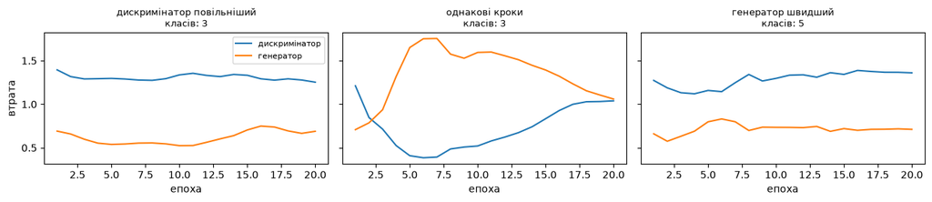

```
конфігурація                   втрата D   втрата G   розмах G   класів
------------------------------------------------------------------------
дискримінатор повільніший        1.2782     0.7071     0.2251        3
однакові кроки                   1.0049     1.1751     1.0466        3
генератор швидший                1.3716     0.7106     0.2563        5
```

```python
figure, axes = plt.subplots(1, len(CONFIGS), figsize=(13, 2.9), sharey=True)
for column, (name, _) in enumerate(CONFIGS):
    losses = np.array(results[name]["losses"])
    axes[column].plot(range(1, len(losses) + 1), losses[:, 0], label="дискримінатор")
    axes[column].plot(range(1, len(losses) + 1), losses[:, 1], label="генератор")
    axes[column].set_title("%s\nкласів: %d" % (name, results[name]["covered"][LAST][0]), fontsize=9)
    axes[column].set_xlabel("епоха")
axes[0].set_ylabel("втрата")
axes[0].legend(fontsize=8)
plt.tight_layout()
plt.show()

print("%-28s %10s %10s %10s %8s" %
      ("конфігурація", "втрата D", "втрата G", "розмах G", "класів"))
print("-" * 72)
for name, _ in CONFIGS:
    losses = np.array(results[name]["losses"])
    tail = losses[-5:]
    print("%-28s %10.4f %10.4f %10.4f %8d" %
          (name, tail[:, 0].mean(), tail[:, 1].mean(),
           losses[:, 1].max() - losses[:, 1].min(), results[name]["covered"][LAST][0]))
```

```python
print("епоха  " + "  ".join("%-19s" % n[:19] for n, _ in CONFIGS))
print("       " + "  ".join("%-19s" % "  втрата D / втрата G" for _ in CONFIGS))
print("-" * 92)
for epoch_index in range(len(results[CONFIGS[0][0]]["losses"])):
    row = "  ".join("%8.4f %8.4f  " % tuple(results[name]["losses"][epoch_index])
                    for name, _ in CONFIGS)
    print("%-6d %s" % (epoch_index + 1, row))
```

```
епоха  дискримінатор повіл  однакові кроки       генератор швидший
         втрата D / втрата G    втрата D / втрата G    втрата D / втрата G
--------------------------------------------------------------------------------------------
1        1.3946   0.6914      1.2113   0.7081      1.2732   0.6602
2        1.3171   0.6579      0.8469   0.7862      1.1879   0.5748
3        1.2902   0.5981      0.7144   0.9364      1.1321   0.6320
4        1.2930   0.5531      0.5249   1.3186      1.1199   0.6902
5        1.2964   0.5385      0.4091   1.6509      1.1581   0.7980
6        1.2894   0.5435      0.3852   1.7518      1.1444   0.8311
7        1.2778   0.5535      0.3935   1.7547      1.2472   0.7986
8        1.2741   0.5552      0.4861   1.5750      1.3419   0.6983
9        1.2933   0.5449      0.5084   1.5281      1.2667   0.7365
10       1.3366   0.5244      0.5205   1.5946      1.2968   0.7345
11       1.3552   0.5256      0.5783   1.5990      1.3336   0.7339
12       1.3308   0.5626      0.6230   1.5562      1.3377   0.7311
13       1.3170   0.6021      0.6736   1.5111      1.3100   0.7448
14       1.3419   0.6394      0.7410   1.4469      1.3620   0.6887
15       1.3322   0.7044      0.8336   1.3927      1.3424   0.7201
16       1.2917   0.7494      0.9275   1.3217      1.3878   0.7005
17       1.2765   0.7380      0.9990   1.2342      1.3762   0.7115
18       1.2915   0.6937      1.0284   1.1545      1.3670   0.7126
19       1.2781   0.6654      1.0309   1.1055      1.3664   0.7174
20       1.2531   0.6892      1.0390   1.0596      1.3606   0.7112
```

## 11 · Чому першим гине кільце

Кільце зникає в усіх конфігураціях. Гіпотеза: справа не у випадковості, а в тому, що кільце **найважче намалювати** — воно найтонше, і невелика неохайність його знищує.

Перевіримо це прямо, без жодного GAN. Візьмемо справжні фігури й зіпсуємо їх однаково для всіх класів: розмиємо кожну однаковим вікном. Потім спитаємо суддю, яку частку кожного класу він ще впізнає. Якщо гіпотеза правильна, кільце обвалиться першим.

```python
@torch.no_grad()
def recognised_share(images, labels, blur_radius):
    # Розмиваємо всі картинки однаково й дивимось, який клас суддя ще впізнає.
    if blur_radius > 0:
        window = 2 * blur_radius + 1
        images = F.avg_pool2d(images, window, stride=1, padding=blur_radius)
    predicted = judge(images).argmax(1)
    return [float((predicted[labels == kind] == kind).float().mean()) for kind in range(6)]


print("%-9s %s" % ("розмиття", "  ".join("%-11s" % n[:11] for n in SHAPE_NAMES)))
print("-" * 78)
fragility = {}
for blur_radius in [0, 1, 2, 3]:
    shares = recognised_share(x_test, y_test, blur_radius)
    fragility[blur_radius] = shares
    print("%-9d %s" % (blur_radius, "  ".join("%-11.3f" % v for v in shares)))

print()
worst = int(np.argmin(fragility[1]))
print("на розмитті 1 найгірше впізнається:", SHAPE_NAMES[worst], "— %.3f" % fragility[1][worst])
print("а частка яскравих пікселів у ньому найменша:", "%.4f" % bright_share[worst],
      "проти %.4f у найтовщої фігури" % max(bright_share))
```

```
розмиття  коло         квадрат      ромб         кільце       хрест        трикутник
------------------------------------------------------------------------------
0         0.970        1.000        1.000        1.000        1.000        1.000
1         0.320        0.950        0.000        0.100        0.010        0.990
```

[output not shown]

## 12 · GAN проти VAE однією метрикою

Тема 37 показала VAE: він теж генерує картинки з випадкового вектора, але вчиться зовсім інакше — мінімізує **похибку відновлення**. Порівняймо їх однією метрикою й на тому самому датасеті.

Щоб порівняння було чесним, VAE дістає **рівно стільки ж епох**, скільки GAN, — двадцять, і той самий латентний простір на 16 чисел. Коефіцієнт `beta`, який керує компромісом VAE, беремо 0.2 — це його власна ручка, і про неї йдеться в темі 37.

Додаємо третє число — **різкість**. Міряємо її просто: частка пікселів, які ані чорні, ані білі (значення між 0.25 і 0.75). У справжніх фігур таких майже немає — межа різка. У розмитої картинки їх багато.

```python
class VAE(nn.Module):
    def __init__(self, latent=LATENT, width=24):
        super().__init__()
        self.width = width
        self.encoder = nn.Sequential(
            nn.Conv2d(1, width // 2, 4, stride=2, padding=1), nn.ReLU(),
            nn.Conv2d(width // 2, width, 4, stride=2, padding=1), nn.ReLU(), nn.Flatten())
        self.to_mean = nn.Linear(width * 49, latent)
        self.to_logvar = nn.Linear(width * 49, latent)
        self.fc = nn.Linear(latent, width * 7 * 7)
        self.decoder = nn.Sequential(
            nn.ReLU(), nn.ConvTranspose2d(width, width // 2, 4, stride=2, padding=1),
            nn.ReLU(), nn.ConvTranspose2d(width // 2, 1, 4, stride=2, padding=1), nn.Sigmoid())

    def decode(self, z):
        return self.decoder(self.fc(z).view(-1, self.width, 7, 7))

    def forward(self, x):
        hidden = self.encoder(x)
        mean, logvar = self.to_mean(hidden), self.to_logvar(hidden)
        z = mean + torch.randn_like(mean) * torch.exp(0.5 * logvar)
        return self.decode(z), mean, logvar


def train_vae(images, seed, epochs=20, batch_size=64, lr=2e-3, beta=0.2):
    torch.manual_seed(seed)
    model = VAE()
    optimizer = torch.optim.AdamW(model.parameters(), lr=lr)
    count = len(images)
    for epoch in range(epochs):
        order = torch.randperm(count)
        for start in range(0, count - batch_size + 1, batch_size):
            batch = images[order[start:start + batch_size]]
            optimizer.zero_grad()
            output, mean, logvar = model(batch)
            # похибка відновлення — та сама явна ціль, якої в GAN немає
            reconstruction = F.mse_loss(output, batch, reduction="sum") / len(batch)
            # розходження Кульбака–Лейблера: тягне хмарку кодів до N(0, 1)
            divergence = -0.5 * (1 + logvar - mean * mean - logvar.exp()).sum() / len(batch)
            (reconstruction + beta * divergence).backward()
            optimizer.step()
    model.eval()
    return model


vae_started = time.perf_counter()
vae_rows = []
for seed in [0, 1, 2]:
    vae = train_vae(x_train, seed)
    with torch.no_grad():
        fixed = torch.Generator().manual_seed(5000 + seed)
        samples = vae.decode(torch.randn(600, LATENT, generator=fixed))
    covered, fid, confidence, _ = score(samples)
    vae_rows.append((covered, fid, confidence, midtone_share(samples)))
    if seed == 0:
        vae_samples = samples
print("три VAE навчено за %.0f с" % (time.perf_counter() - vae_started))
for seed, row in enumerate(vae_rows):
    print("VAE зерно %d: класів %d  FID %.2f  впевненість %.4f  напівтони %.4f" % (seed, *row))
```

```
три VAE навчено за 33 с
VAE зерно 0: класів 6  FID 299.01  впевненість 0.8381  напівтони 0.0878
VAE зерно 1: класів 6  FID 289.35  впевненість 0.8389  напівтони 0.0890
VAE зерно 2: класів 5  FID 398.99  впевненість 0.8453  напівтони 0.1006
```

```python
gan_best = "генератор швидший"
gan_samples = results[gan_best]["samples"]
gan_plain_samples = results["однакові кроки"]["samples"]

print("%-18s %8s %10s %12s %12s" %
      ("модель", "класів", "FID", "напівтони", "впевненість"))
print("-" * 66)
print("%-18s %8.2f %10.2f %12.4f %12.4f" %
      ("справжні", 6.0, real_baseline_fid, midtone_share(x_test), calibration_rows[0][3]))
print("%-18s %8.2f %10.2f %12.4f %12.4f" %
      ("VAE", np.mean([r[0] for r in vae_rows]), np.mean([r[1] for r in vae_rows]),
       np.mean([r[3] for r in vae_rows]), np.mean([r[2] for r in vae_rows])))
print("%-18s %8.2f %10.2f %12.4f %12.4f" %
      ("GAN (найкращий)", np.mean(results[gan_best]["covered"][LAST]),
       np.mean(results[gan_best]["fid"][LAST]),
       np.mean(results[gan_best]["midtones"][LAST]),
       np.mean(results[gan_best]["confidence"][LAST])))
print("%-18s %8.2f %10.2f %12.4f %12.4f" %
      ("GAN (базовий)", np.mean(results["однакові кроки"]["covered"][LAST]),
       np.mean(results["однакові кроки"]["fid"][LAST]),
       np.mean(results["однакові кроки"]["midtones"][LAST]),
       np.mean(results["однакові кроки"]["confidence"][LAST])))
print()
print("покриття по зернах: VAE %s, GAN найкращий %s, GAN базовий %s"
      % ([r[0] for r in vae_rows], results[gan_best]["covered"][LAST],
         results["однакові кроки"]["covered"][LAST]))
print("напівтони по зернах: VAE %s, GAN найкращий %s"
      % ([round(r[3], 4) for r in vae_rows],
         [round(v, 4) for v in results[gan_best]["midtones"][LAST]]))
```

```
модель               класів        FID    напівтони  впевненість
------------------------------------------------------------------
справжні               6.00       1.16       0.0000       0.9899
VAE                    5.67     329.12       0.0925       0.8408
GAN (найкращий)        4.67     249.33       0.0578       0.8116
GAN (базовий)          3.00     569.69       0.0595       0.8213

покриття по зернах: VAE [6, 6, 5], GAN найкращий [5, 5, 4], GAN базовий [3, 3, 3]
напівтони по зернах: VAE [0.0878, 0.089, 0.1006], GAN найкращий [0.0454, 0.0469, 0.0811]
```

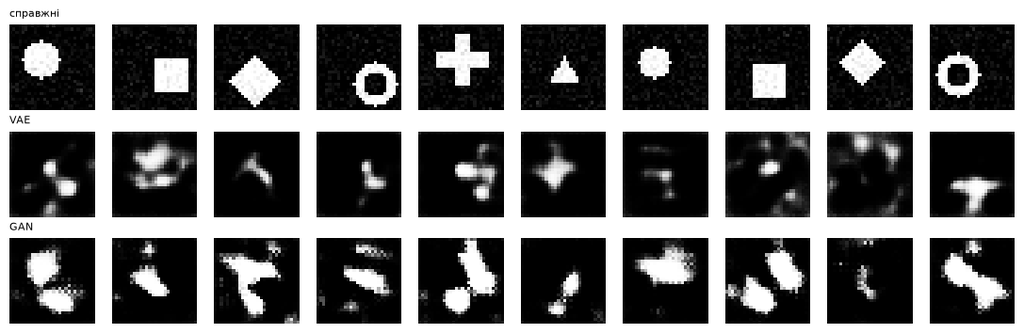

```
напівтонів у справжніх: 0.0000
напівтонів у VAE      : 0.0878
напівтонів у GAN      : 0.0454
тобто GAN різкіший за VAE у 1.9 раза
```

```python
figure, axes = plt.subplots(3, 10, figsize=(11, 3.6))
for column in range(10):
    axes[0, column].imshow(x_test[column, 0], cmap="gray", vmin=0, vmax=1)
    axes[1, column].imshow(vae_samples[column, 0], cmap="gray", vmin=0, vmax=1)
    axes[2, column].imshow(gan_samples[column, 0], cmap="gray", vmin=0, vmax=1)
    for row in range(3):
        axes[row, column].axis("off")
axes[0, 0].set_title("справжні", fontsize=8, loc="left")
axes[1, 0].set_title("VAE", fontsize=8, loc="left")
axes[2, 0].set_title("GAN", fontsize=8, loc="left")
plt.tight_layout()
plt.show()
print("напівтонів у справжніх: %.4f" % midtone_share(x_test))
print("напівтонів у VAE      : %.4f" % midtone_share(vae_samples))
print("напівтонів у GAN      : %.4f" % midtone_share(gan_samples))
print("тобто GAN різкіший за VAE у %.1f раза"
      % (midtone_share(vae_samples) / midtone_share(gan_samples)))
```

## 13 · Що зошит показав

```python
print("1. Ненасичена втрата дає при D = 0.0180 градієнт у %.1f раза більший."
      % (saturation_table[0][3] / saturation_table[0][2]))
print("2. Суддя на справжніх фігурах: %.4f. Базова лінія FID: %.4f."
      % (judge_accuracy, real_baseline_fid))
print("3. Метрика ставить повний колапс («лише кола») у %.0f разів гірше за базову лінію."
      % (circles_only_fid / real_baseline_fid))
print("4. Базовий GAN покриває %.2f класи з шести; купа по зернах %s."
      % (np.mean(results["однакові кроки"]["covered"][LAST]),
         results["однакові кроки"]["covered"][LAST]))
print("5. Сповільнення дискримінатора зробило гірше: %.2f, купа %s."
      % (np.mean(results["дискримінатор повільніший"]["covered"][LAST]),
         results["дискримінатор повільніший"]["covered"][LAST]))
print("6. Прискорення генератора допомогло: %.2f, купа %s — купи не перетинаються."
      % (np.mean(results["генератор швидший"]["covered"][LAST]),
         results["генератор швидший"]["covered"][LAST]))
print("7. Найвпевненіший суддя — на найгіршій конфігурації: %.4f проти %.4f у найкращої."
      % (np.mean(results["дискримінатор повільніший"]["confidence"][LAST]),
         np.mean(results["генератор швидший"]["confidence"][LAST])))
print()
print("час усього зошита: %.0f с" % (time.perf_counter() - notebook_started))
```

```
1. Ненасичена втрата дає при D = 0.0180 градієнт у 54.6 раза більший.
2. Суддя на справжніх фігурах: 0.9950. Базова лінія FID: 1.1582.
3. Метрика ставить повний колапс («лише кола») у 418 разів гірше за базову лінію.
4. Базовий GAN покриває 3.00 класи з шести; купа по зернах [3, 3, 3].
5. Сповільнення дискримінатора зробило гірше: 2.33, купа [3, 3, 1].
6. Прискорення генератора допомогло: 4.67, купа [5, 5, 4] — купи не перетинаються.
7. Найвпевненіший суддя — на найгіршій конфігурації: 0.9129 проти 0.8116 у найкращої.

час усього зошита: 249 с
```

## Завдання

### 🟢 Рівень 1

Додай до таблиці калібрування ще один завідомо поганий набір: **лише кільця**. Порівняй його FID із «лише кола». Чи однаково метрика карає колапс на різні класи?

**Зроблено, якщо:** у таблиці зʼявився новий рядок і ти можеш сказати, який із двох колапсів метрика вважає гіршим і чому.

### 🟡 Рівень 2

Прожени конфігурацію «генератор швидший» ще з двома значеннями `lr_generator` (наприклад `3e-4` і `1e-3`) на тих самих трьох зернах. Побудуй залежність покриття від швидкості генератора.

**Зроблено, якщо:** є таблиця з трьох-чотирьох точок із розкидом по зернах, і ти можеш сказати, чи це монотонна залежність, чи в неї є максимум.

### 🔴 Рівень 3

Заміни втрату генератора на **насичену** — `log(1 - D)` замість `-log D` — і навчи GAN у конфігурації «однакові кроки» на трьох зернах.

**Зроблено, якщо:** ти показуєш, що сталося з покриттям і з кривою втрат, і повʼязуєш це з таблицею градієнтів із першого розділу зошита.